# Project 1

Justin Feathers

2022-09-07

# Created Functions

This calls necessary packages

```r
require(tidyverse)
library(readr)
```

This creates a function to perform steps 1 & 2

```r
long <- function(df = sheet1, x = "enrollment"){
  sheet2 <<- df %>%
  select(Area_name, STCOU, ends_with("D")) %>%
  pivot_longer(cols = ends_with("D"), names_to = x, values_to = "us_total")
}
```

This creates a function using the output of step 2 to perform step 3

```r
strings <- function(df = sheet2){
tempYear <- df[[3]] %>%
  substr(8, 9)

year <- if_else(tempYear >= 23, paste0("19", tempYear), paste0("20", tempYear)) %>%
  as.numeric()

measurement <- df[[3]] %>%
  substr(1, 7)

sheet3 <<- mutate(df, year = year, measurement = measurement)
}
```

This creates a function to perform step 5

```r
addState <- function(df = county){
  x <- df$Area_name %>%
    substr(nchar(df$Area_name)-1, nchar(df$Area_name))
  finalCounty <<- mutate(df, state = x)
  }
```

This creates a function to perform step 6

```r
div <- function(df = nonCounty){
  y <- df$Area_name
  division <- if_else(y %in% c("CONNECTICUT", "MAINE", "MASSACHUSETTS", "NEW HAMPSHIRE",
                 "RHODE ISLAND","VERMONT"), "New England",
    if_else(y %in% c("NEW JERSEY", "NEW YORK", "PENNSYLVANIA"), "Mid-Atlantic",
    if_else(y %in% c("ILLINOIS", "INDIANA", "MICHIGAN", "OHIO", "WISCONSIN"), "East North Central",
    if_else(y %in% c("IOWA", "KANSAS", "MINNESOTA", "MISSOURI", "NEBRASKA",
                 "NORTH DAKOTA", "SOUTH DAKOTA"), "West North Central",
    if_else(y %in% c("DELAWARE", "FLORIDA", "GEORGIA", "MARYLAND", "NORTH CAROLINA",
                 "SOUTH CAROLINA", "VIRGINIA", "DISTRICT OF COLUMBIA",
                 "District of Columbia", "WEST VIRGINIA"), "South Atlantic",
    if_else(y %in% c("ALABAMA", "KENTUCKY", "MISSISSIPPI", "TENNESSEE"), "East South Central",
    if_else(y %in% c("ARKANSAS", "LOUISIANA", "OKLAHOMA", "TEXAS"), "West South Central",
    if_else(y %in% c("ARIZONA", "COLORADO", "IDAHO", "MONTANA", "NEVADA", "NEW MEXICO",
                  "UTAH", "WYOMING"), "Moutain",
    if_else(y %in% c("ALASKA", "CALIFORNIA", "HAWAII", "OREGON", "WASHINGTON"), "Pacific", "ERROR")))))))))
  finalNonCounty <<- mutate(df, division = division)
}
```

This creates a function using the output from step 3 to perform step 4, call steps 5 and 6, and return 2 tibbles

```r
final <- function(df = sheet3){
  county <<- df[grep(pattern = ", \\w\\w", df$Area_name), ]
  nonCounty <<- df[grepl(pattern = ", \\w\\w", df$Area_name) == 0, ]
  class(county) <<- c("county", class(county))
  class(nonCounty) <<- c("state", class(nonCounty))
  list(addState(), div())
}
```

This creates a wrapper function to call multiple functions with a single call

```r
myWrapper <- function(url, x = "enrollment"){
sheet1 <<- read_csv(url)
long(, x)
strings()
final()
}
```

This calls the wrapper function using the first .csv file and saves the output as a single object consisting of 2 tibbles

```r
a <- myWrapper("https://www4.stat.ncsu.edu/~online/datasets/EDU01a.csv")
```

This calls the wrapper function using the second .csv file and saves the output as a single object consisting of 2 tibbles that are different from the previous code chunk

```r
b <- myWrapper("https://www4.stat.ncsu.edu/~online/datasets/EDU01b.csv")
```

This uses the results of both wrapper calls and combines the tibbles for county and nonCounty

```r
combining <- function(df1, df2){
  comCounty <- dplyr::bind_rows(df1[[1]], df2[[1]])
  comNonCounty <- dplyr::bind_rows(df1[[2]], df2[[2]])
  comData <<- list(comCounty, comNonCounty)
  }
```

This creates a function to plot the state data

```r
plotState <- function(df = comData[[2]], z = "us_total"){
  df %>%
    group_by(division, year) %>%
    summarize(mean = mean(get(z))) %>%
    filter(division != "ERROR") %>%
    ggplot(aes(x = year, y = mean, color = division)) + geom_line()
}
```

This creates a function to plot the county data

```r
plotCounty <- function(df= comData[[1]], st = "PA", z = "us_total", tb = "top", x = 5){
  tempdf <- df %>%
    filter(state == st) %>%
    group_by(Area_name) %>%
    summarize(mean = mean(get(z)))
  tempdf2 <- if(tb == "top") {
    arrange(tempdf, desc(mean)) %>% head(x)
  } else if(tb == "bottom") {
    arrange(tempdf, desc(mean)) %>% tail(x)
  } else stop("tb= needs 'top' or 'bottom' as input")
  tempdf3 <- df %>%
    group_by(Area_name, year)
  finaldf <- tempdf3[df$Area_name %in% tempdf2$Area_name, ]
  ggplot(finaldf, aes(x = year, y = get(z), color = Area_name)) + geom_line()
}
```

# Put it Together

This calls the wrapper function using the first .csv file with a different x value and saves the output as a list of 2 tibbles

```r
a <- myWrapper("https://www4.stat.ncsu.edu/~online/datasets/EDU01a.csv", x = "Measure&Year")
```

This calls the wrapper function using the second .csv file and saves the output as a list of 2 different tibbles

```r
b <- myWrapper("https://www4.stat.ncsu.edu/~online/datasets/EDU01b.csv", x = "Measure&Year")
```

This combines the county tibbles and nonCounty tibbles from the first 2 .csv files

```r
combining(a, b)
```

This plots the state data using the plotState function for the 1st and 2nd URLs

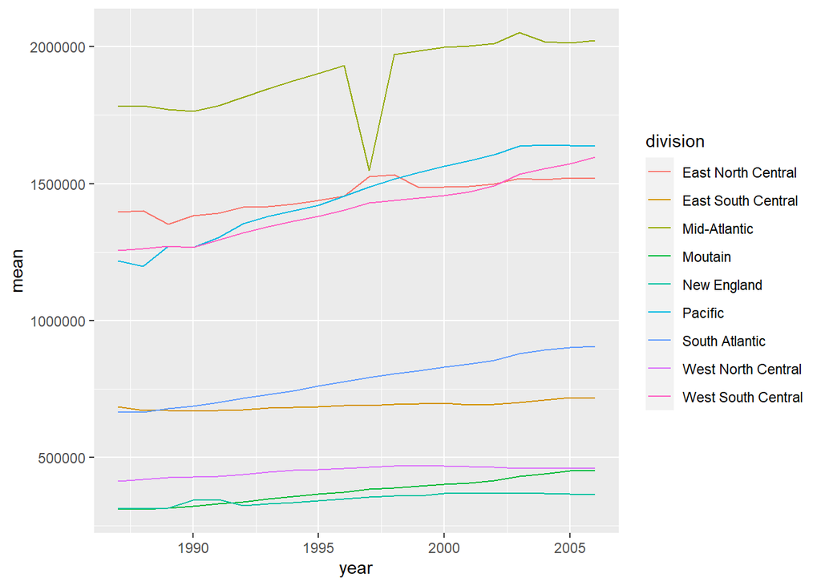

```r
plotState()
```

This plots the county data using the plotCounty function for the 1st and 2nd URLs for:

specifying the state to be “PA”, the group being the top, the number looked at being 7

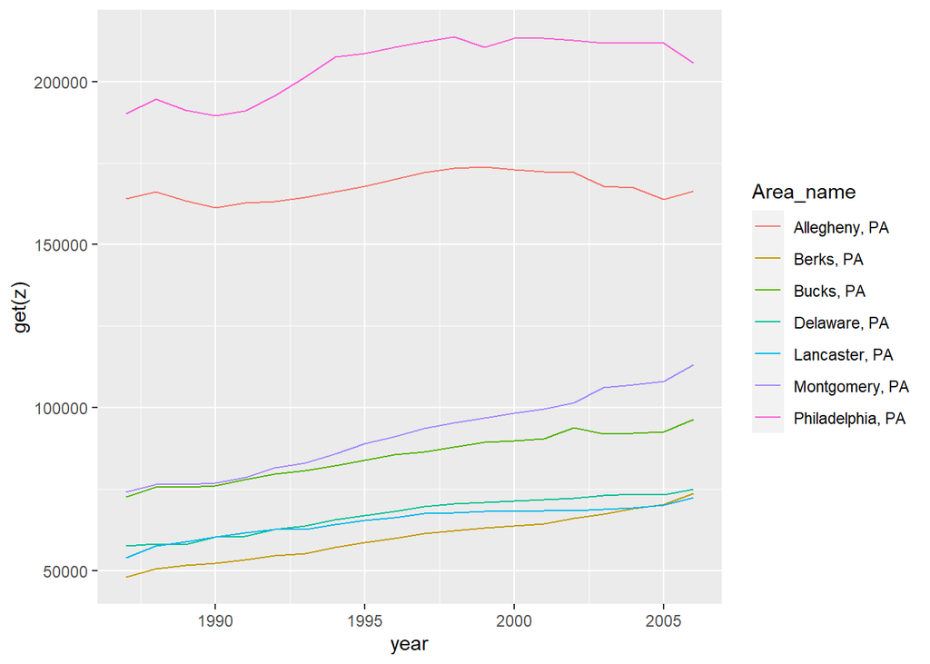

```r
plotCounty(st = "PA", x = 7)
```

specifying the state to be “PA”, the group being the bottom, the number looked at being 4

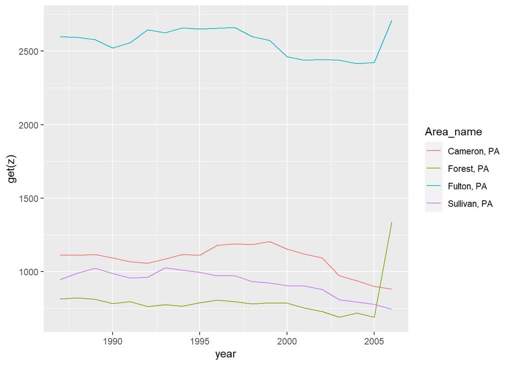

```r
plotCounty(st = "PA", tb = "bottom", x = 4)
```

without specifying anything (defaults used)

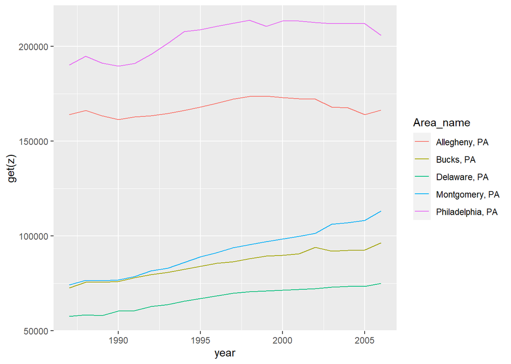

```r
plotCounty()
```

specifying the state to be “MN”, the group being the top, the number looked at being 10

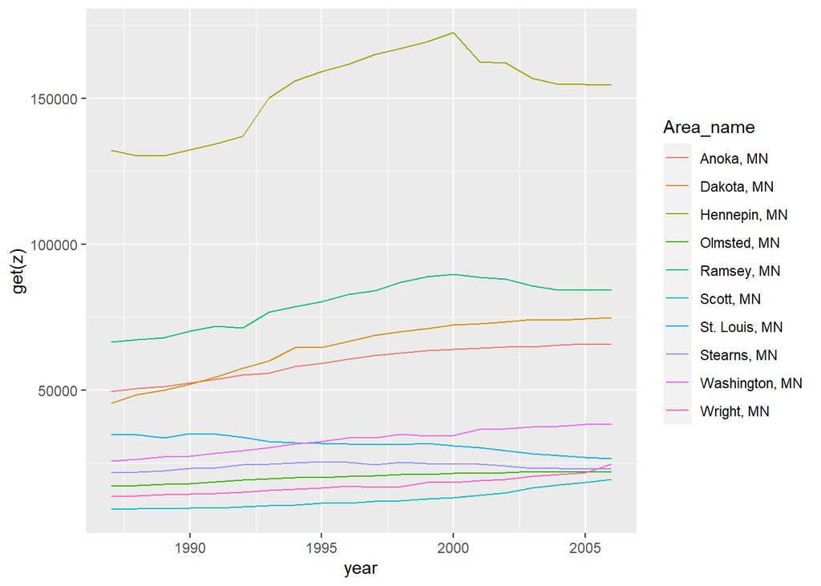

```r
plotCounty(st = "MN", x = 10)
```

This runs the wrapper on the 3rd URL

```r
a <- myWrapper("https://www4.stat.ncsu.edu/~online/datasets/PST01a.csv")
```

This runs the wrapper on the 4th URL

```r
b <- myWrapper("https://www4.stat.ncsu.edu/~online/datasets/PST01b.csv")
```

This combines the datasets from the 3rd and 4th URLs

```r
tempCom1 <- combining(a, b)
```

This runs the wrapper on the 5th URL

```r
a <- myWrapper("https://www4.stat.ncsu.edu/~online/datasets/PST01c.csv")
```

This runs the wrapper on the 6th URL

```r
b <- myWrapper("https://www4.stat.ncsu.edu/~online/datasets/PST01d.csv")
```

This combines the datasets from the 5th and 6th URLs

```r
tempCom2 <- combining(a, b)
```

This combines tempCom1 and tempCom2 in order to combine the 3rd, 4th, 5th, and 6th URLs into one object

```r
combining(tempCom1, tempCom2)
```

This plots the combined state data for URLs 3, 4, 5, and 6

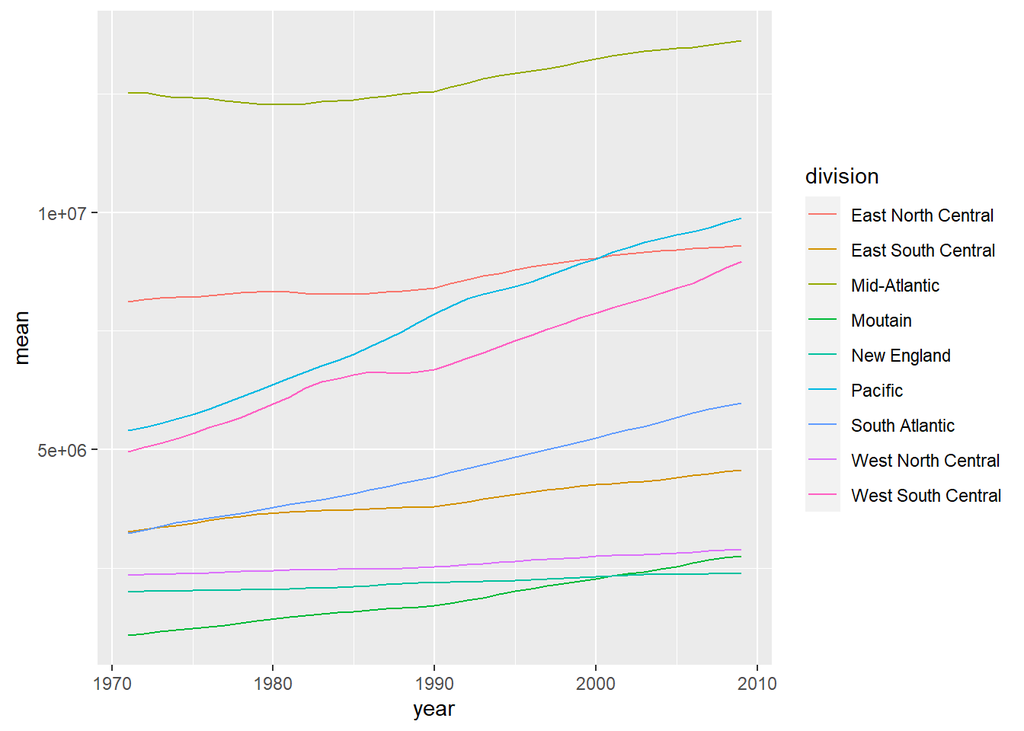

```r
plotState()
```

This plots the combined county data for URLs 3, 4, 5, and 6 for:

specifying the state to be “CT”, the group being the top, the number looked at being 6

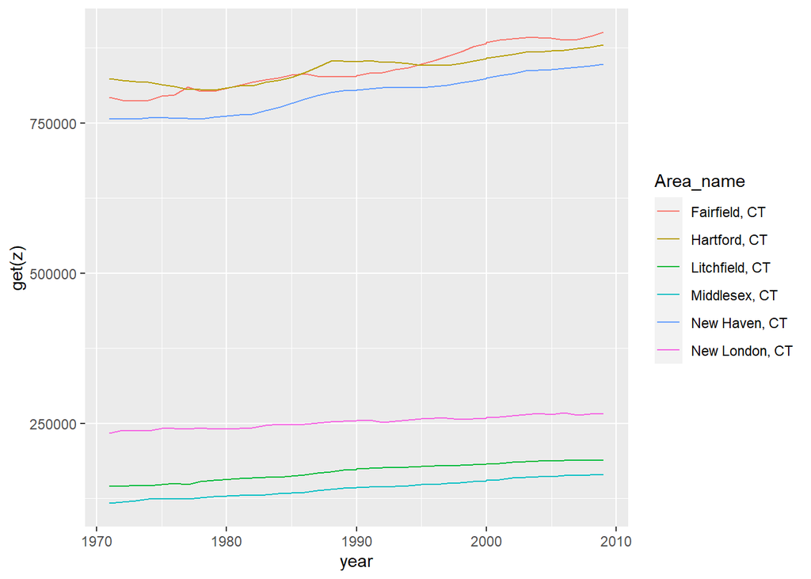

```r
plotCounty(st = "CT", x = 6)
```

specifying the state to be “NC”, the group being the bottom, the number looked at being 10

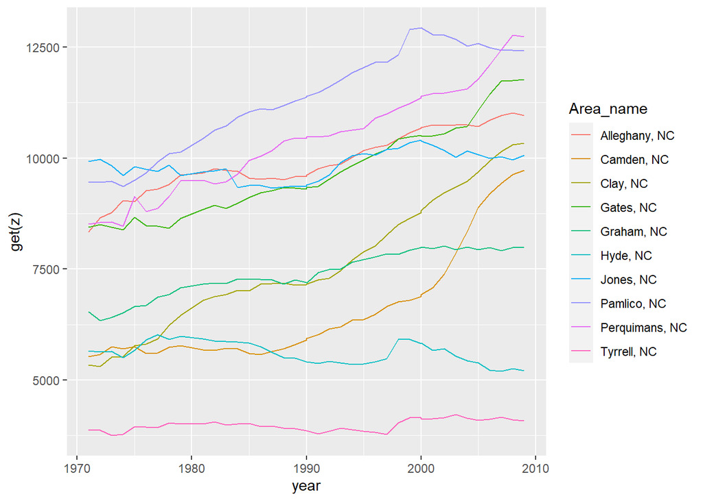

```r
plotCounty(st = "NC", tb = "bottom", x = 10)
```

without specifying anything (defaults used)

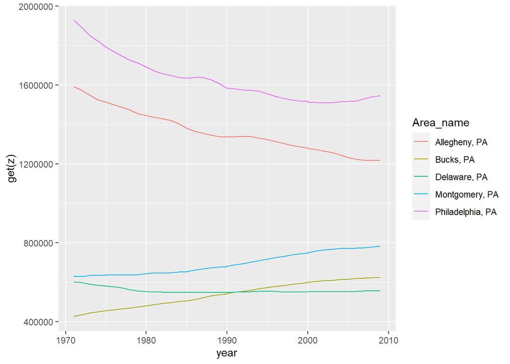

```r
plotCounty()
```

specifying the state to be “MN”, the group being the top, the number looked at being 4

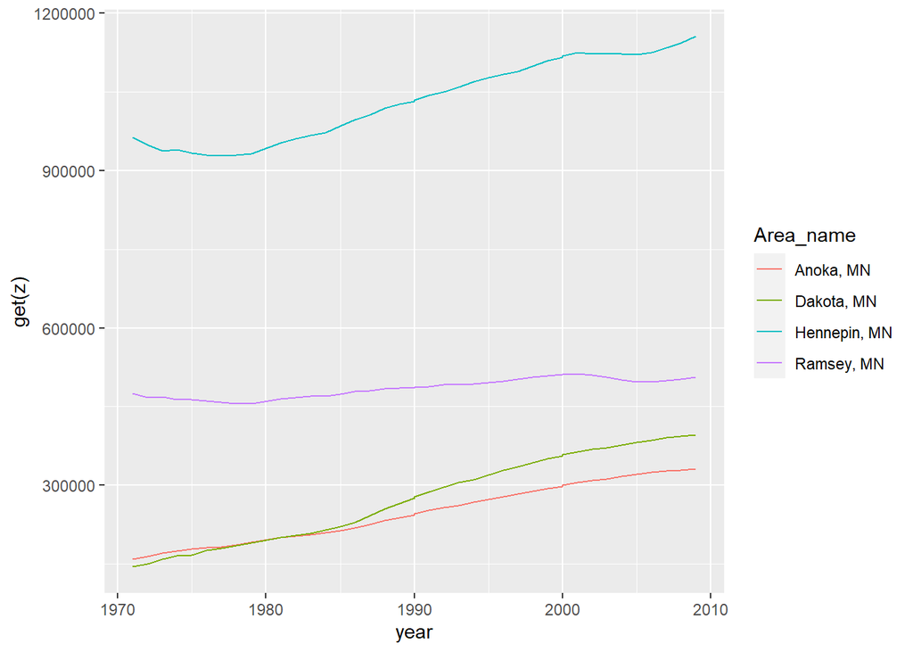

```r
plotCounty(st = "MN", x = 4)
```